# Hw6

Apoorva Srinivasan

11/25/2018

### Problem 1

```r
library(tidyverse)
set.seed(1)
homicide = read.csv( file = "./data/homicide-data.csv")
```

### data cleaning

```r
homicide= homicide%>%
  janitor::clean_names()%>%
  mutate(city_state = str_c(city, ",", state)) %>%
  subset(!city_state %in% c("Dallas,TX","Phoenix,AZ","Kansas City,MO","Tulsa,AL"))%>%
  mutate(victim_race = ifelse(victim_race != "White", "non-white", "white"))%>%
  mutate(victim_age = as.numeric(victim_age), victim_race = fct_relevel(victim_race, "white"))
```

After data cleaning, the tidy dataset consists 48507 rows by 13 columns.

### Balimore glm

```r
Baltimore = filter(homicide, city_state == "Baltimore,MD") %>%
mutate(resolved = as.numeric(disposition == "Closed by arrest")) %>%
select(resolved, victim_age, victim_race, victim_sex)

balt_log =
  Baltimore %>%
  glm(resolved ~ victim_age + victim_race + victim_sex, data = ., family = binomial())%>%
  broom::tidy()%>%
  mutate(OR = exp(estimate), conf.low = exp(estimate - qnorm(0.975)*std.error), conf.high = exp(estimate + qnorm(0.975)*std.error))%>%
  filter(term == "victim_racenon-white")%>%
  select(term,OR, conf.low,conf.high)

knitr::kable(balt_log)
```

| term | OR | conf.low | conf.high |
| --- | --- | --- | --- |
| victim_racenon-white | 0.4525206 | 0.3216203 | 0.6366977 |

### glm for all the cities

```r
homicide_subset = homicide %>%
  filter(victim_race != "unknown") %>% ##removing unknown victim race
  mutate(resolved = as.numeric(disposition == "Closed by arrest"))

cities_log =
  homicide_subset %>%
  group_by(city_state) %>%
  nest() %>%
  mutate(models = map(data, ~glm(resolved ~ victim_age + victim_race + victim_sex, data = .x, family = binomial())),
         models = map(models, broom::tidy)) %>%
  select(-data) %>%
  unnest() %>%
  mutate(OR = exp(estimate), conf.low = exp(estimate - qnorm(0.975)*std.error), conf.high = exp(estimate + qnorm(0.975)*std.error)) %>%
  filter(term == "victim_racenon-white") %>%
  select(city_state,term,OR, conf.low,conf.high)

knitr::kable(cities_log)
```

| city_state | term | OR | conf.low | conf.high |
| --- | --- | --- | --- | --- |
| Albuquerque,NM | victim_racenon-white | 0.6860531 | 0.4176974 | 1.1268177 |
| Atlanta,GA | victim_racenon-white | 0.7667500 | 0.4404305 | 1.3348431 |
| Baltimore,MD | victim_racenon-white | 0.4525206 | 0.3216203 | 0.6366977 |
| Baton Rouge,LA | victim_racenon-white | 0.6558545 | 0.3074103 | 1.3992540 |
| Birmingham,AL | victim_racenon-white | 1.0471153 | 0.6226928 | 1.7608210 |
| Boston,MA | victim_racenon-white | 0.1205147 | 0.0496325 | 0.2926265 |
| Buffalo,NY | victim_racenon-white | 0.4474175 | 0.2455018 | 0.8154008 |
| Charlotte,NC | victim_racenon-white | 0.5550724 | 0.3250654 | 0.9478259 |
| Chicago,IL | victim_racenon-white | 0.5751690 | 0.4412489 | 0.7497341 |
| Cincinnati,OH | victim_racenon-white | 0.3269424 | 0.1896835 | 0.5635248 |
| Columbus,OH | victim_racenon-white | 0.8844860 | 0.6571179 | 1.1905254 |
| Denver,CO | victim_racenon-white | 0.5942632 | 0.3530866 | 1.0001761 |
| Detroit,MI | victim_racenon-white | 0.6609813 | 0.4958081 | 0.8811801 |
| Durham,NC | victim_racenon-white | 1.1528002 | 0.4605931 | 2.8852976 |
| Fort Worth,TX | victim_racenon-white | 0.8527376 | 0.5646722 | 1.2877586 |
| Fresno,CA | victim_racenon-white | 0.4574375 | 0.2364814 | 0.8848439 |
| Houston,TX | victim_racenon-white | 0.9207334 | 0.7385854 | 1.1478022 |
| Indianapolis,IN | victim_racenon-white | 0.5162217 | 0.3904413 | 0.6825223 |
| Jacksonville,FL | victim_racenon-white | 0.6805895 | 0.5192932 | 0.8919855 |
| Las Vegas,NV | victim_racenon-white | 0.7883387 | 0.6133300 | 1.0132848 |
| Long Beach,CA | victim_racenon-white | 0.8428440 | 0.4125283 | 1.7220296 |
| Los Angeles,CA | victim_racenon-white | 0.7176698 | 0.5245423 | 0.9819036 |
| Louisville,KY | victim_racenon-white | 0.4336608 | 0.2880114 | 0.6529661 |
| Memphis,TN | victim_racenon-white | 0.8066744 | 0.5410241 | 1.2027626 |
| Miami,FL | victim_racenon-white | 0.5768849 | 0.3792390 | 0.8775371 |
| Milwaukee,wI | victim_racenon-white | 0.6598363 | 0.4218686 | 1.0320369 |
| Minneapolis,MN | victim_racenon-white | 0.6665973 | 0.3546810 | 1.2528216 |
| Nashville,TN | victim_racenon-white | 0.8919720 | 0.6483510 | 1.2271348 |
| New Orleans,LA | victim_racenon-white | 0.5105893 | 0.3258202 | 0.8001390 |
| New York,NY | victim_racenon-white | 0.5481259 | 0.2883233 | 1.0420316 |
| Oakland,CA | victim_racenon-white | 0.2174194 | 0.1066222 | 0.4433524 |
| Oklahoma City,OK | victim_racenon-white | 0.7114617 | 0.5034421 | 1.0054339 |
| Omaha,NE | victim_racenon-white | 0.1795682 | 0.0993429 | 0.3245803 |
| Philadelphia,PA | victim_racenon-white | 0.6615811 | 0.4997395 | 0.8758354 |
| Pittsburgh,PA | victim_racenon-white | 0.2896680 | 0.1657623 | 0.5061919 |
| Richmond,VA | victim_racenon-white | 0.4882646 | 0.1827844 | 1.3042815 |
| San Antonio,TX | victim_racenon-white | 0.6983376 | 0.4686104 | 1.0406841 |
| Sacramento,CA | victim_racenon-white | 0.7743855 | 0.4470800 | 1.3413099 |
| Savannah,GA | victim_racenon-white | 0.6437600 | 0.3135579 | 1.3216921 |
| San Bernardino,CA | victim_racenon-white | 0.9462056 | 0.4259392 | 2.1019550 |
| San Diego,CA | victim_racenon-white | 0.4339041 | 0.2668576 | 0.7055177 |
| San Francisco,CA | victim_racenon-white | 0.4577118 | 0.2901083 | 0.7221444 |
| St. Louis,MO | victim_racenon-white | 0.6010156 | 0.4239148 | 0.8521048 |
| Stockton,CA | victim_racenon-white | 0.3954507 | 0.2078314 | 0.7524428 |
| Tampa,FL | victim_racenon-white | 1.1845998 | 0.6121675 | 2.2923083 |
| Tulsa,OK | victim_racenon-white | 0.5857297 | 0.4021897 | 0.8530285 |
| Washington,DC | victim_racenon-white | 0.5268148 | 0.2666560 | 1.0407935 |

### Visualization

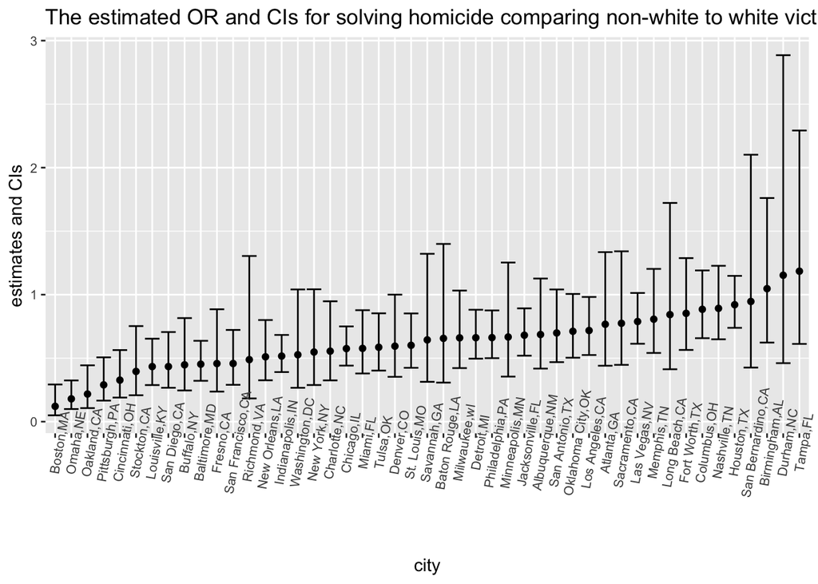

```r
cities_log %>%
            mutate(city_state = fct_reorder(city_state, OR))%>%
            ggplot(aes(x = city_state, y = OR))+
            geom_point()+
            geom_errorbar(aes(ymin = conf.low, ymax= conf.high))+
            theme(axis.text.x =  element_text(angle = 80))+
            labs(
              title = "The estimated OR and CIs for solving homicide comparing non-white to white victims across the U.S.",
              x = "city",
              y = "estimates and CIs"
            ) +
    theme(axis.text = element_text(size = 8))
```

From the plot above, we can see that the adjusted OR in most cities (44 out of 47) of solving homicides comparing non-white to white victims is less than 1. That is, in most cities, homicides with non-white victim are less likely to be solved than those with white victims. Also, cities with higher OR estimate tend to have wider confidence interval. For example, estimates of Durham is less precise than Boston since it’s confidence interval is much higher.

### Problem 2

#### data loading and tidying

```r
birthweight = read_csv("./data/birthweight.csv") %>%
  mutate(babysex = as.factor(babysex),
         babysex = recode_factor(babysex, `1` = "Male", `2` = "Female")) %>%
  mutate(frace = as.factor(frace),
         frace = recode_factor(frace, `1` = "White", `2` = "Black", `3` = "Asian", `4` = "Puerto Rican", `8` = "Other", `9` = "Unknown")) %>%
 mutate(mrace = as.factor(mrace),
        mrace = recode_factor(mrace, `1` = "White", `2` = "Black", `3` = "Asian", `4` = "Puerto Rican", `8` = "Other")) %>%
  mutate(malform = as.factor(malform),
         malform = recode_factor(malform, `0` = "Absent", `1` = "Present"))
###checking if there are missing values

birthweight %>% is.na() %>% sum
```

```
## [1] 0
```

```r
##There are no missing values
```

Propose a regression model for birthweight. This model may be based on a hypothesized structure for the factors that underly birthweight, on a data-driven model-building process, or a combination of the two. Describe your modeling process and show a plot of model residuals against fitted values – use add_predictions and add_residuals in making this plot.

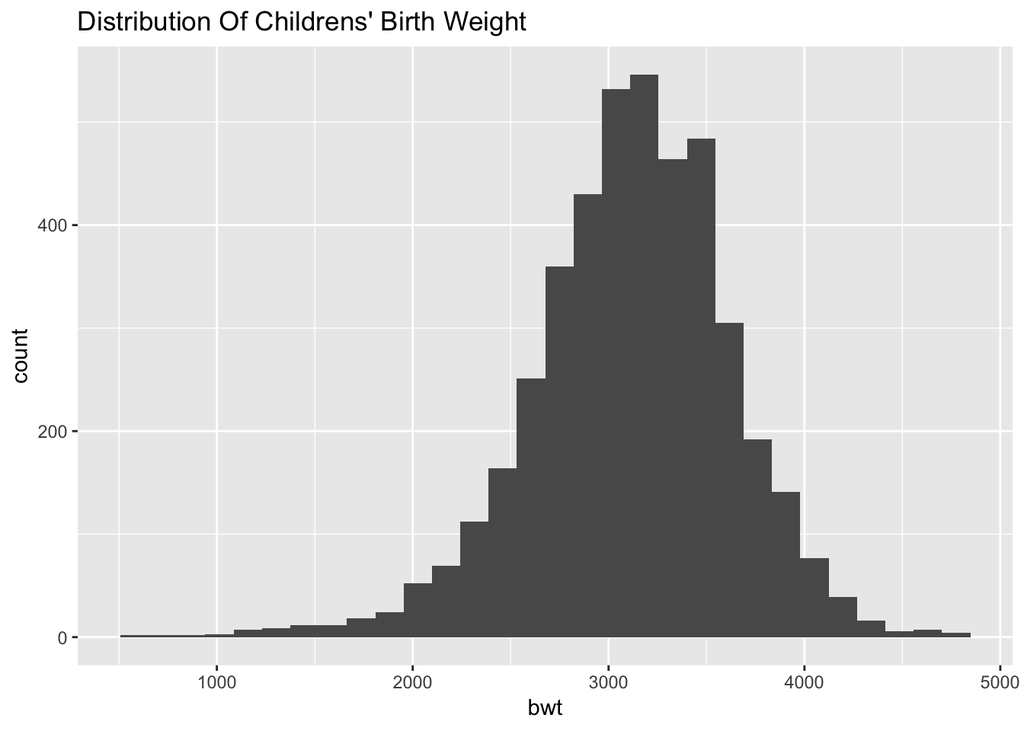

```r
###Visualization
birthweight %>%
  ggplot(aes(x=bwt))+
  geom_histogram()+
  labs(title="Distribution Of Childrens' Birth Weight")
```

The birthweight from the above graph is normally distributed

To build a model for birthweight, we will use backward elimication i.e start with all the predictors in stepwise/automatic approach to identify best subsets.

```r
mult_fit = lm(bwt ~ ., data=birthweight)
step(mult_fit, direction='backward') %>%
  broom::tidy()
```

```
## Start:  AIC=48717.83
## bwt ~ babysex + bhead + blength + delwt + fincome + frace + gaweeks +
##     malform + menarche + mheight + momage + mrace + parity +
##     pnumlbw + pnumsga + ppbmi + ppwt + smoken + wtgain
##
##
## Step:  AIC=48717.83
## bwt ~ babysex + bhead + blength + delwt + fincome + frace + gaweeks +
##     malform + menarche + mheight + momage + mrace + parity +
##     pnumlbw + pnumsga + ppbmi + ppwt + smoken
##
##
## Step:  AIC=48717.83
## bwt ~ babysex + bhead + blength + delwt + fincome + frace + gaweeks +
##     malform + menarche + mheight + momage + mrace + parity +
##     pnumlbw + ppbmi + ppwt + smoken
##
##
## Step:  AIC=48717.83
## bwt ~ babysex + bhead + blength + delwt + fincome + frace + gaweeks +
##     malform + menarche + mheight + momage + mrace + parity +
##     ppbmi + ppwt + smoken
##
##            Df Sum of Sq       RSS   AIC
## - frace     4    124365 320848704 48712
## - malform   1      1419 320725757 48716
## - ppbmi     1      6346 320730684 48716
## - momage    1     28661 320752999 48716
## - mheight   1     66886 320791224 48717
## - menarche  1    111679 320836018 48717
## - ppwt      1    131132 320855470 48718
## <none>                  320724338 48718
## - fincome   1    193454 320917792 48718
## - parity    1    413584 321137922 48721
## - mrace     3    868321 321592659 48724
## - babysex   1    853796 321578134 48727
## - gaweeks   1   4611823 325336161 48778
## - smoken    1   5076393 325800732 48784
## - delwt     1   8008891 328733230 48823
## - blength   1 102050296 422774634 49915
```

[output cut: 88 more lines]

```
##     mheight + mrace + parity + ppwt + smoken
##
##           Df Sum of Sq       RSS   AIC
## <none>                 320986412 48705
## - fincome  1    245637 321232048 48707
## - parity   1    422770 321409181 48709
## - babysex  1    846134 321832545 48715
## - mheight  1   1012240 321998651 48717
## - ppwt     1   2907049 323893461 48743
## - gaweeks  1   4662501 325648912 48766
## - smoken   1   5073849 326060260 48771
## - delwt    1   8137459 329123871 48812
## - mrace    3  14683609 335670021 48894
## - blength  1 102191779 423178191 49903
## - bhead    1 106779754 427766166 49950
```

```
## # A tibble: 14 x 5
##    term               estimate std.error statistic   p.value
##    <chr>                 <dbl>     <dbl>     <dbl>     <dbl>
##  1 (Intercept)       -6099.      138.       -44.3  0.
##  2 babysexFemale        28.6       8.45       3.38 7.37e-  4
##  3 bhead               131.        3.45      37.9  3.10e-272
##  4 blength              74.9       2.02      37.1  4.29e-262
##  5 delwt                 4.11      0.392     10.5  2.26e- 25
##  6 fincome               0.318     0.175      1.82 6.88e-  2
##  7 gaweeks              11.6       1.46       7.93 2.79e- 15
##  8 mheight               6.59      1.78       3.69 2.23e-  4
##  9 mraceBlack         -139.        9.91     -14.0  1.21e- 43
## 10 mraceAsian          -74.9      42.3       -1.77 7.68e-  2
## 11 mracePuerto Rican  -101.       19.3       -5.21 1.98e-  7
## 12 parity               96.3      40.3        2.39 1.70e-  2
## 13 ppwt                 -2.68      0.427     -6.26 4.20e- 10
## 14 smoken               -4.84      0.586     -8.27 1.75e- 16
```

Given a collection of models for the data, AIC estimates the quality of each model, relative to each of the other models. We need to choose the model with smallest AIC.

The desired model is: bwt ~ babysex + bhead + blength + delwt + fincome + gaweeks + mheight + mrace + parity + ppwt + smoken

with smallest AIC of 48705.38

Hence, my model is

```r
my_model = lm(bwt ~ babysex + bhead + blength + delwt + fincome +  gaweeks + mheight + parity + ppwt + smoken + mrace, data = birthweight)
summary(my_model)
```

```
##
## Call:
## lm(formula = bwt ~ babysex + bhead + blength + delwt + fincome +
##     gaweeks + mheight + parity + ppwt + smoken + mrace, data = birthweight)
##
## Residuals:
##      Min       1Q   Median       3Q      Max
## -1097.18  -185.52    -3.39   174.14  2353.44
##
## Coefficients:
##                     Estimate Std. Error t value Pr(>|t|)
## (Intercept)       -6098.8219   137.5463 -44.340  < 2e-16 ***
## babysexFemale        28.5580     8.4549   3.378 0.000737 ***
## bhead               130.7770     3.4466  37.944  < 2e-16 ***
## blength              74.9471     2.0190  37.120  < 2e-16 ***
## delwt                 4.1067     0.3921  10.475  < 2e-16 ***
## fincome               0.3180     0.1747   1.820 0.068844 .
## gaweeks              11.5925     1.4621   7.929 2.79e-15 ***
## mheight               6.5940     1.7849   3.694 0.000223 ***
## parity               96.3047    40.3362   2.388 0.017004 *
## ppwt                 -2.6756     0.4274  -6.261 4.20e-10 ***
## smoken               -4.8434     0.5856  -8.271  < 2e-16 ***
## mraceBlack         -138.7925     9.9071 -14.009  < 2e-16 ***
## mraceAsian          -74.8868    42.3146  -1.770 0.076837 .
## mracePuerto Rican  -100.6781    19.3247  -5.210 1.98e-07 ***
## ---
## Signif. codes:  0 '***' 0.001 '**' 0.01 '*' 0.05 '.' 0.1 ' ' 1
##
## Residual standard error: 272.3 on 4328 degrees of freedom
## Multiple R-squared:  0.7181, Adjusted R-squared:  0.7173
## F-statistic: 848.1 on 13 and 4328 DF,  p-value: < 2.2e-16
```

Plotting my model residuals against fitted values

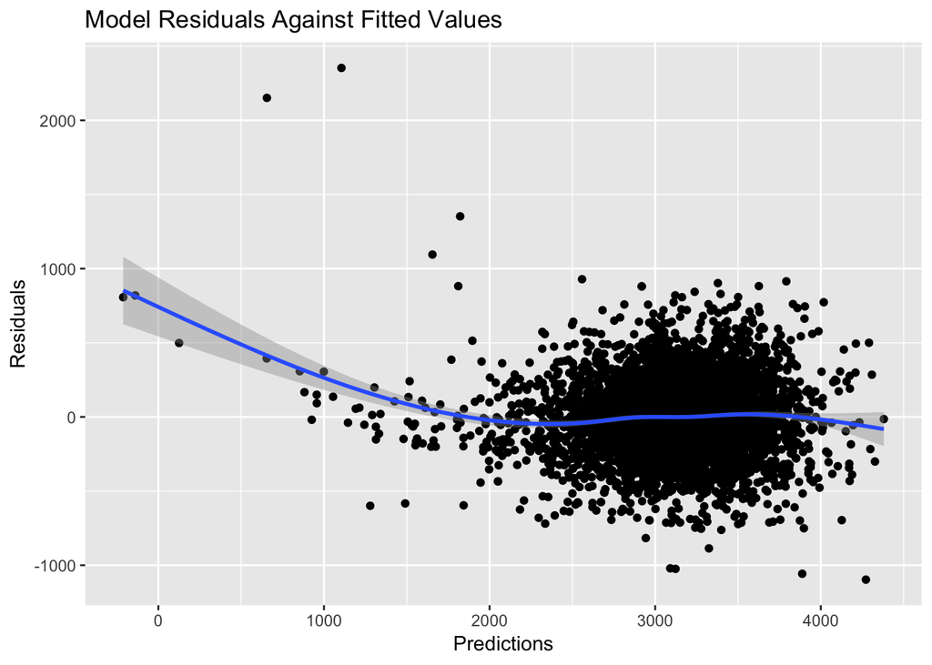

```r
birthweight %>%
  add_predictions(my_model) %>%
  add_residuals(my_model) %>%
  ggplot(aes(x = pred, y = resid)) +
  geom_point() +
  geom_smooth() +
  labs(title = "Model Residuals Against Fitted Values",
        x = "Predictions",
        y = "Residuals")
```

Comparing my model with two other suggested models: **model_2**: using length at birth and gestational age as predictors (main effects only)

**bwt ~ blength + gaweeks**

**model_3** : using head circumference, length, sex, and all interactions (including the three-way interaction) between these.

__bwt ~ babysex + bhead + blength + babysex*bhead + babysex*blength + bhead*blength + babysex*bhead*blength__

```r
model_2 = lm(bwt ~ blength + gaweeks, data = birthweight)
model_3 = lm(bwt ~ babysex + bhead + blength + babysex*bhead + babysex*blength + bhead*blength + babysex*bhead*blength , data = birthweight)


sum1=summary(my_model)$adj.r.squared
sum2=summary(model_2)$adj.r.squared
sum3=summary(model_3)$adj.r.squared
adj_r_squared<- matrix(c(sum1,sum2,sum3),ncol=1,byrow=TRUE)
colnames(adj_r_squared) = c("Adjusted R-squared")
rownames(adj_r_squared) = c("my_model","model_2","model_3")
adj_r_squared<- as.table(adj_r_squared)
adj_r_squared
```

```
##          Adjusted R-squared
## my_model          0.7172529
## model_2           0.5766943
## model_3           0.6843670
```

My model has the highest R squared from the table above.

Comparing in terms of the cross-validated prediction error

```r
cross_validation =
  crossv_mc(birthweight, 1000) %>%
  mutate(train = map(train, as_tibble),
         test = map(test, as_tibble)) %>%
  mutate(my_model = map(train, ~lm(bwt ~ babysex + bhead + blength + delwt + fincome +  gaweeks + mheight + parity + ppwt + smoken + mrace, data = birthweight)),
         model_2 = map(train, ~lm(bwt ~ blength + gaweeks, data = birthweight)),
         model_3 = map(train, ~lm(bwt ~ babysex + bhead + blength + babysex*bhead + babysex*blength + bhead*blength + babysex*bhead*blength , data = birthweight)),
         rmse_1 = map2_dbl(my_model, test, ~rmse(model = .x, data = .y)),
         rmse_2 = map2_dbl(model_2, test, ~rmse(model = .x, data = .y)),
         rmse_3 = map2_dbl(model_3, test, ~rmse(model = .x, data = .y)))
```

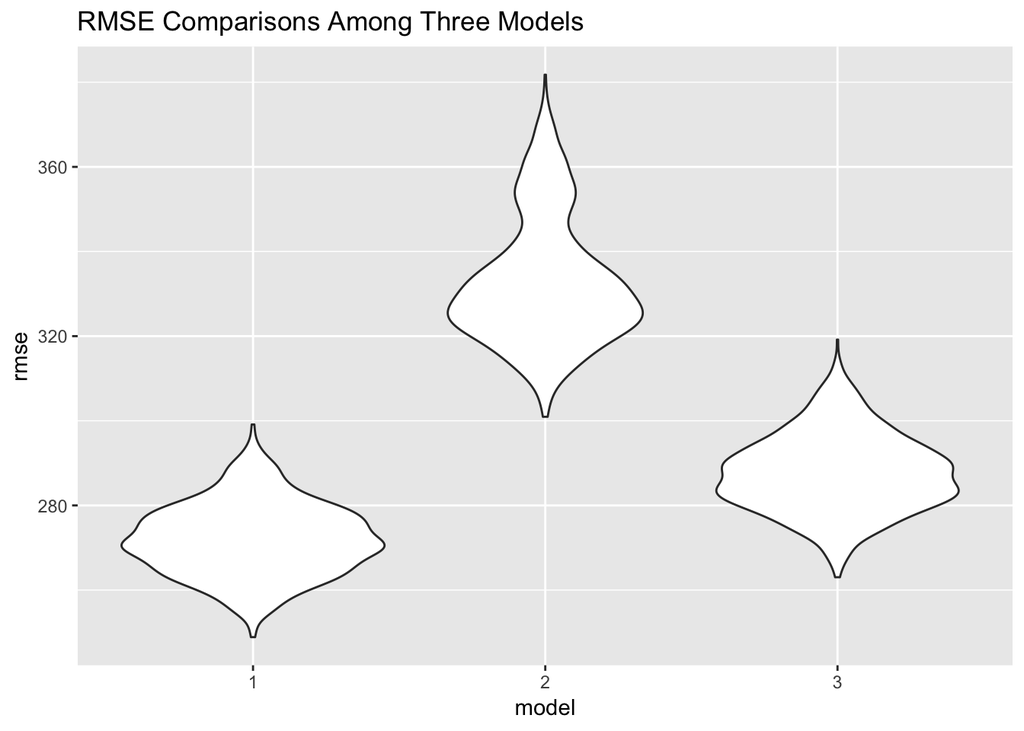

```r
rmse_plot = cross_validation %>%
  dplyr::select(starts_with("rmse")) %>%
  gather(key = model, value = rmse) %>%
  mutate(model = str_replace(model, "rmse_", ""),
         model = fct_inorder(model)) %>%
  ggplot(aes(x = model, y = rmse)) + geom_violin() +
  labs(title="RMSE Comparisons Among Three Models")

rmse_plot
```

According to the violin plot above,the first model has lowest RMSE among the three. Low RMSE indicates that a model has small differences between predicted values and obseved values.Therefore, I’d pick the first model over the other two.